# Regresión Avanzada 2024

Trabajo Práctico Final

Jorge Nicolau

# Preprocesamiento de Datos

Dado que no todos los componentes del dataset están en formato tabular se requiere la conversión para poder combinar los datos de las diferentes partes. Antes proceder con la combinación se pasa de formato JSON a CSV los archivos `train_fraud_labels.json` y `mcc_codes.json`.

El archivo resultante `train_fraud_labels.csv` servirá para la combinación de los datos de fraude con el dataset principal, mientras que `mcc_codes.csv` servirá para la conversión de los códigos de categoría de comercio a texto.

El código de conversión de JSON a CSV está escrito en Python porque maneja mejor la lectura de archivos grandes. Se sabe que el archivo JSON tienen una estructura simple con un solo nivel de anidamiento que dificulta la lectura con R por línea como se muesrta a continuación:

```json
{"target": {"10649266": "No", "23410063": "No", "9316588": "No", "12478022": "No", "9558530": "No", "12532830": "No", "19526714": "No", "9906964": "No", "13224888": "No", "13749094": "No", "12303776": "No", "19480376": "No", "11716050": "No", "20025400": "No", "7661688": "No", "16662807": "No", "21419778": "No", "18011186": "No", "23289598": "No", "11644547": "No", "23235120": "No", "19748218": "No", "8720720": "No", "18335831": "No", "18936727": "No", "15223870": "No"}}
```

La aproximación con lectura por bytes tampoco es eficiente, por lo que se decidió usar Python para la conversión del archivo `train_fraud_labels.json` de 151,7 MB de tamaño.

### Conversión de `train_fraud_labels.json` a `train_fraud_labels.csv`

```python
# Dataset: Financial Transactions Dataset: Analytics
# Archivo principal con informacion de 13.305.915 transacciones en 1.2 GB
# Source: https://www.kaggle.com/datasets/computingvictor/transactions-fraud-datasets

import json
import csv
from tqdm import tqdm

def json_to_csv(json_data, output_csv):
    # Cargar los datos JSON
    with open(json_data, 'r') as json_file:
        data = json.load(json_file)

    # Asegurarse de que la clave 'target' esté en los datos JSON
    if 'target' not in data:
        raise ValueError("El JSON no contiene la clave 'target'")

    # Obtener los pares de ID y valor de 'target'
    target_data = data['target']

    # Escribir los datos en un archivo CSV
    with open(output_csv, 'w', newline='') as csv_file:
        writer = csv.writer(csv_file)
        writer.writerow(['transaction_id', 'fraud'])  # Escribir los encabezados

        for transaction_id, fraud in tqdm(target_data.items(), desc="Procesando registros", unit="registro"):
            writer.writerow([transaction_id, fraud])

# Ejemplo de uso
json_to_csv('train_fraud_labels.json', 'train_fraud_labels.csv')
```

La cantidad de registros en el archivo `train_fraud_labels.json` es de 8.914.963, inferior al archivo principal de transacciones con 13.305.915 registros dado que son etiquetas sólo para el conjunto de entrenamiento.

### Conversión de `mcc_codes.json` a `mcc_codes.csv`

Para este archivo se puede usar R para la conversión ya que es un archivo pequeño y simple.

```r
library(jsonlite)
library(progress)
library(data.table)

# Función para convertir JSON a CSV usando data.table y mostrar progreso
convert_json_file_to_csv_with_progress <- function(input_json_file, output_csv_file) {
  # Leer el JSON desde el archivo
  json_data <- fromJSON(input_json_file)

  # Crear un data.table vacío para almacenar los resultados
  data <- data.table(Code = character(), Description = character())

  # Inicializar el progreso
  pb <- progress_bar$new(
    format = "  Procesando [:bar] :percent en :elapsed segundos",
    total = length(json_data),
    clear = FALSE,
    width = 60
  )

  # Iterar sobre los elementos del JSON
  for (code in names(json_data)) {
    pb$tick() # Actualizar el progreso
    data <- rbind(data, data.table(Code = code, Description = json_data[[code]]))
  }

  # Guardar el data.table como CSV
  fwrite(data, file = output_csv_file, row.names = FALSE)

  message("El archivo CSV se ha guardado como: ", output_csv_file)
}

# Llamar a la función con nombres de archivo
input_json_file <- "mcc_codes.json" # Cambia por el nombre de tu archivo JSON
output_csv_file <- "mcc_codes.csv" # Cambia por el nombre deseado del archivo CSV
convert_json_file_to_csv_with_progress(input_json_file, output_csv_file)
```

## Filtrar y Muestrear Datos de Transacciones

Una vez que se han convertido los archivos JSON a CSV, se procede a filtrar y muestrear los datos de transacciones para obtener un subconjunto que contenga la misma proporcion de estados y transsacciones fraudulentas que el conjunto original.

En primer lugar, se carga el dataset original y el de fraude, se unen por la columna correspondiente (el id de transacción).

```r
library(dplyr)
library(readr)

# Leer los datos
transactions_data <- read_csv("transactions_data.csv")
train_fraud_labels <- read_csv("train_fraud_labels.csv")

# Prefijo para las columnas del conjunto de fraude
colnames(train_fraud_labels) <- paste0("fd_", colnames(train_fraud_labels))

# Unir los datos por las columnas correspondientes
merged_data <- left_join(transactions_data, train_fraud_labels,
                          by = c("id" = "fd_transaction_id"))
```

Luego, se calcula el tamaño de la muestra a obtener (1% del total) y se muestrea manteniendo las proporciones de estados y transacciones fraudulentas.

```r
# Calcular el 1% del total
total_rows <- nrow(merged_data)
sample_size <- floor(total_rows * 0.01)

# Muestrear manteniendo proporciones
set.seed(999901)
sampled_data <- merged_data %>%
  group_by(merchant_state, fd_fraud) %>%
  sample_frac(min(sample_size / total_rows, 1))

# Guardar los datos muestreados
write_csv(sampled_data, "sampled_transactions.csv")

# Mostrar los datos resultantes
print(str(sampled_data))
```

## Construcción del Dataset Completo

Con la muestra del 1% del dataset de transacciones con etiquetas de fraude, se procede a unir los datos de georreferencias, códigos postales, tarjetas, usuarios y códigos de categoría de comercio (MCC) para construir un dataset completo que contenga toda la información necesaria para el análisis.

Primero se cargan los datos de georreferencias de estados de USA y se los une al dataset de transacciones por la abreviatura de estado (codigo de dos letras).

```r
library(dplyr)
library(readr)

# Leer los datos de transacciones
transactions_data <- read_csv("sampled_transactions.csv")
print(str(transactions_data))

# Dataset: USA States (Generalized)
# Source https://public-data-hub-dhhs.hub.arcgis.com/datasets/usa-states-generalized/about
# Leer los datos de georreferencias de estados de USA
georef_data <- read_delim("usa_states_generalized.csv", delim = ",")
# Agregar un prefijo a los nombres de columnas para identificar
# que son datos de georreferencias
colnames(georef_data) <- paste0("st_", colnames(georef_data))
# Pasar a minuscúlas todos los nombres de columnas
colnames(georef_data) <- tolower(colnames(georef_data))
# Convertir los espacios en nombres de columnas a guiones bajos
colnames(georef_data) <- gsub(" ", "_", colnames(georef_data))
print(str(georef_data))

# Unir los datos por abreviatura de estado
merged_data <- transactions_data %>%
  left_join(georef_data, by = c("merchant_state" = "st_abbreviation"))
# Revisar dataset resultante
print(str(merged_data))
```

Luego, se unen los datos de códigos postales al dataset resultante.

```r
# Dataset: US Zip Codes Points- United States of America
# Source: https://data.opendatasoft.com/explore/dataset/georef-united-states-of-america-zc-point%40public
# Leer los datos de códigos postales
zip_data <- read_delim("georef_usa_zc_point.csv", delim = ";")
# Agregar un prefijo a los nombres de columnas para identificar
# que son datos de la tabla de códigos postales
colnames(zip_data) <- paste0("zp_", colnames(zip_data))
# Pasar a minuscúlas todos los nombres de columnas
colnames(zip_data) <- tolower(colnames(zip_data))
# Convertir los espacios en nombres de columnas a guiones bajos
colnames(zip_data) <- gsub(" ", "_", colnames(zip_data))
print(str(zip_data))

# Unir los datos por código postal
merged_data <- merged_data %>%
  left_join(zip_data, by = c("zip" = "zp_zip_code"))
# Revisar dataset resultante
print(str(merged_data))
```

A continuación, se unen los datos de tarjetas y usuarios al dataset resultante.

```r
# Leer los datos de tarjetas
cards_data <- read_csv("cards_data.csv")
# Agregar un prefijo a los nombres de columnas para identificar
# que son datos de la tabla de tarjetas
colnames(cards_data) <- paste0("cd_", colnames(cards_data))
print(str(cards_data))

# Unir los datos por ID de tarjeta
merged_data <- merged_data %>%
  left_join(cards_data, by = c("card_id" = "cd_id"))
# Revisar dataset resultante
print(str(merged_data))
```

```r
# Leer los datos de usuarios
users_data <- read_csv("users_data.csv")
# Agregar un prefijo a los nombres de columnas para identificar
# que son datos de la tabla de usuarios
colnames(users_data) <- paste0("ud_", colnames(users_data))
print(str(users_data))

# Unir los datos por ID de cliente
merged_data <- merged_data %>%
  left_join(users_data, by = c("client_id" = "ud_id"))
# Revisar dataset resultante
print(str(merged_data))
```

```r
# Leer los datos de MCC
mcc_data <- read_csv("mcc_codes.csv")
# Agregar un prefijo a los nombres de columnas para identificar
# que son datos de la tabla de códigos de categoría de comercio
colnames(mcc_data) <- paste0("mcc_", colnames(mcc_data))
# Pasar a minuscúlas todos los nombres de columnas
colnames(mcc_data) <- tolower(colnames(mcc_data))
print(str(mcc_data))

# Unir los datos por MCC
merged_data <- merged_data %>%
  left_join(mcc_data, by = c("mcc" = "mcc_code"))
# Revisar dataset resultante
print(str(merged_data))

# Guardar los datos completos
write_csv(merged_data, "transactions_data_complete.csv")
```

El dataset completo resultante se guarda en un archivo CSV llamado `transactions_data_complete.csv` que contiene toda la información combinada de transacciones, georreferencias, códigos postales, tarjetas, usuarios y códigos de categoría de comercio resultan en 110 parámetros con esta estructura:

```r
print(str(merged_data, list.len = Inf))
```

## Depuración de Columnas Redundantes

Previsiblemente luego de comoponer el dataset de diferentes fuentes se generan campos claramente redundantes que duplican información o podrían estar correlacionados, por lo que en base al análisis de los datos se procede a eliminar las columnas redundantes.

```r
# Leer los datos completos de transacciones
merged_data <- read_csv("transactions_data_complete.csv")
print(str(merged_data, list.len = Inf))
```

```r
# Eliminar columnas redundantes
merged_data <- merged_data %>%
  select(-cd_client_id, -cd_card_number, -zp_official_usps_city_name,
         -zp_official_usps_state_code, -zp_primary_official_county_name,
         -zp_official_county_name, -st_name, -st_med_age_m,
         -st_med_age_f, -zp_official_state_name, -st_pop2010,
         -st_pop._per_sq._mi., -st_pop10_sqmi)

# Renombrar columnas
colnames(merged_data) <- gsub("st_population_\\(2017\\)", "st_population", colnames(merged_data))
# Revisar dataset resultante
print(str(merged_data, list.len = Inf))
```

## Depuración de campos parcialmente redundantes o derivados

En estos casos los campos podrían estar ser derivados unos de otros, lo que podría implicar redundancia.

```r
# Eliminar columnas parcialmente redundantes
merged_data <- merged_data %>%
  select(-zp_density, -ud_current_age, -st_shape__area, -st_shape__length, -ud_address, -zp_timezone,
         -st_white, -st_black, -st_ameri_es, -st_asian, -st_hawn_pi, -st_hispanic, -st_other)

# Convertir latitud y longitud a un punto geográfico
merged_data$ud_geo_point <- paste(merged_data$ud_latitude, merged_data$ud_longitude, sep = ",")
# Eliminar latitud y longitud
merged_data <- merged_data %>%
  select(-ud_latitude, -ud_longitude)

# Convertir millas cuadradas a kilómetros cuadrados
merged_data$st_sqkm <- merged_data$st_sqmi * 2.58999

# Eliminar columnas de millas cuadradas
merged_data <- merged_data %>%
  select(-st_sqmi)
# Revisar dataset resultante
print(str(merged_data, list.len = Inf))
```

## Depuración de campos potencialmente no necesarios para el análisis

Algunos campos parecen específicos y pueden no ser útiles en todos los análisis:

- `st_fips` (Federal Information Processing Standard), `zp_official_county_code`, `zp_primary_official_county_code`, `st_globalid`, `zp_zcta`, `zp_zcta_parent`, `zp_imprecise`, `zp_military`: Estos son identificadores administrativos que podrían no ser útiles para el análisis demografico.
- `zp_county_weights`: Si no se está trabajando con pesos específicos, podría omitirse.
- `cd_cvv`: Este campo no suele ser útil en análisis y puede representar un riesgo de seguridad.

```r
# Eliminar columnas potencialmente no necesarias
merged_data <- merged_data %>%
  select(-st_fips, -zp_official_county_code, -zp_primary_official_county_code, -zp_county_weights, -cd_cvv, -st_globalid, -zp_zcta, -zp_zcta_parent, -zp_imprecise, -zp_military)
# Revisar dataset resultante
print(str(merged_data, list.len = Inf))
```

El dataset depurado resultante a partir del cual se hace el analisis exploratorio de datos econtiene 73 columnas y 1% (133034) de las transacciones originales.

## Corrección de Formato

Para tener suficiente información sobre los datos, se procede a corregir el formato de las columnas que contienen información relevante para el análisis. - `amount`, `cd_credit_limit`, `ud_per_capita_income`, `ud_yearly_income` y `ud_total_debt` se elimina el símbolo $ y se convierten a numérico.

```r
# Corregir el formato de las columnas
merged_data$amount <- as.numeric(gsub("\\$", "", merged_data$amount))
merged_data$cd_credit_limit <- as.numeric(gsub("\\$", "", merged_data$cd_credit_limit))
merged_data$ud_per_capita_income <- as.numeric(gsub("\\$", "", merged_data$ud_per_capita_income))
merged_data$ud_yearly_income <- as.numeric(gsub("\\$", "", merged_data$ud_yearly_income))
merged_data$ud_total_debt <- as.numeric(gsub("\\$", "", merged_data$ud_total_debt))

# Convertir las columnas a numérico
merged_data <- merged_data %>%
  mutate(across(c(amount, cd_credit_limit, ud_per_capita_income, ud_yearly_income, ud_total_debt), as.numeric))

# Mostar la estructura del dataset limpio
print(str(merged_data, list.len = Inf))

# Guardar los datos limpios
write_csv(merged_data, "transactions_data_clean.csv")
```

# Análisis Exploratorio de Datos

Para realizar un análisis exploratorio de los datos, se cargan los datos completos y se realizan algunas visualizaciones y cálculos descriptivos.

```r
library(ggplot2)
library(dplyr)
library(ggplot2)
library(readr)
library(skimr)

# Leer los datos completos
transactions_data <- read_csv("transactions_data_clean.csv")
# Resumen de los datos con skimr solo variables numéricas
transactions_data_num <- transactions_data %>%
  select_if(is.numeric)
skimr::skim(transactions_data_num)
```

Data summary

| Name | transactions_data_num |
| --- | --- |
| Number of rows | 133034 |
| Number of columns | 56 |
| _______________________ |  |
| Column type frequency: |  |
| numeric | 56 |
| ________________________ |  |
| Group variables | None |

**Variable type: numeric**

| skim_variable | n_missing | complete_rate | mean | sd | p0 | p25 | p50 | p75 | p100 | hist |
| --- | --- | --- | --- | --- | --- | --- | --- | --- | --- | --- |
| id | 0 | 1.00 | 15583754.35 | 4704252.31 | 7475442.00 | 11507995.75 | 15568248.00 | 19656920.00 | 23761863.00 | ▇▇▇▇▇ |
| client_id | 0 | 1.00 | 1023.65 | 582.15 | 0.00 | 514.25 | 1067.00 | 1528.00 | 1998.00 | ▇▇▇▇▇ |
| card_id | 0 | 1.00 | 3476.54 | 1676.86 | 0.00 | 2412.00 | 3590.00 | 4929.00 | 6138.00 | ▅▃▇▇▇ |
| amount | 0 | 1.00 | 42.95 | 81.36 | -500.00 | 8.85 | 28.91 | 63.89 | 2975.56 | ▇▁▁▁▁ |
| merchant_id | 0 | 1.00 | 47595.03 | 25723.94 | 22.00 | 25887.00 | 45926.00 | 67440.00 | 100340.00 | ▅▇▆▆▅ |
| zip | 16508 | 0.88 | 51329.07 | 29405.92 | 1002.00 | 28590.00 | 47711.00 | 77901.00 | 99928.00 | ▆▇▆▆▇ |
| mcc | 0 | 1.00 | 5565.30 | 876.19 | 1711.00 | 5300.00 | 5499.00 | 5812.00 | 9402.00 | ▁▁▇▁▁ |
| st_fid | 16508 | 0.88 | 26.78 | 15.12 | 1.00 | 13.00 | 29.00 | 41.00 | 51.00 | ▇▃▇▇▆ |
| st_population | 16508 | 0.88 | 14839044.06 | 11838982.49 | 598332.00 | 6104335.00 | 10304250.00 | 20619313.00 | 39611295.00 | ▇▆▃▂▂ |
| st_mult_race | 16508 | 0.88 | 464100.21 | 538779.43 | 10753.00 | 127901.00 | 237765.00 | 585849.00 | 1815384.00 | ▇▃▁▁▂ |
| st_males | 16508 | 0.88 | 6849993.71 | 5453851.19 | 284222.00 | 2791762.00 | 4729171.00 | 9377147.00 | 18517830.00 | ▇▅▂▂▂ |
| st_females | 16508 | 0.88 | 7058491.62 | 5522745.87 | 276189.00 | 2981790.00 | 4958482.00 | 10000955.00 | 18736126.00 | ▇▆▃▂▂ |
| st_age_under5 | 16508 | 0.88 | 922551.49 | 766227.42 | 31952.00 | 364488.00 | 632040.00 | 1155822.00 | 2531333.00 | ▇▅▂▂▂ |
| st_age_5_9 | 16508 | 0.88 | 926352.87 | 757978.19 | 26147.00 | 366868.00 | 637784.00 | 1163955.00 | 2505839.00 | ▇▅▂▂▂ |
| st_age_10_14 | 16508 | 0.88 | 945349.32 | 774502.04 | 25041.00 | 379029.00 | 675216.00 | 1211456.00 | 2590930.00 | ▇▅▂▂▂ |
| st_age_15_19 | 16508 | 0.88 | 1010922.33 | 833336.50 | 38142.00 | 406241.00 | 709999.00 | 1366278.00 | 2823940.00 | ▇▅▂▂▂ |
| st_age_20_24 | 16508 | 0.88 | 989369.26 | 818017.22 | 40318.00 | 393698.00 | 669072.00 | 1410935.00 | 2765949.00 | ▇▅▂▂▂ |
| st_age_25_34 | 16508 | 0.88 | 1894399.33 | 1584962.80 | 69622.00 | 762042.00 | 1246593.00 | 2659337.00 | 5317877.00 | ▇▅▂▂▂ |
| st_age_35_44 | 16508 | 0.88 | 1884608.59 | 1531072.79 | 66966.00 | 748616.00 | 1327151.00 | 2610017.00 | 5182710.00 | ▇▆▃▂▂ |
| st_age_45_54 | 16508 | 0.88 | 2001348.05 | 1532749.00 | 75703.00 | 842546.00 | 1391252.00 | 2878691.00 | 5252371.00 | ▇▆▃▂▂ |
| st_age_55_64 | 16508 | 0.88 | 1587476.27 | 1170630.73 | 63977.00 | 695768.00 | 1138761.00 | 2337668.00 | 4036493.00 | ▇▆▃▂▂ |
| st_age_65_74 | 16508 | 0.88 | 939329.00 | 678721.63 | 35350.00 | 386357.00 | 697567.00 | 1472256.00 | 2275336.00 | ▇▆▂▃▃ |
| st_age_75_84 | 16508 | 0.88 | 567669.00 | 414616.59 | 14877.00 | 223159.00 | 394948.00 | 866467.00 | 1370210.00 | ▇▅▂▃▂ |
| st_age_85_up | 16508 | 0.88 | 239109.81 | 179132.98 | 4711.00 | 99917.00 | 179611.00 | 390874.00 | 600968.00 | ▇▃▂▂▂ |
| st_med_age | 16508 | 0.88 | 37.19 | 2.02 | 29.20 | 35.30 | 37.30 | 38.70 | 42.70 | ▁▂▇▇▂ |
| st_households | 16508 | 0.88 | 5081685.37 | 3705480.07 | 226879.00 | 2156411.00 | 3745155.00 | 7420802.00 | 12577498.00 | ▇▆▃▂▂ |
| st_ave_hh_sz | 16508 | 0.88 | 2.59 | 0.16 | 2.11 | 2.48 | 2.52 | 2.66 | 3.10 | ▁▇▆▃▁ |
| st_hsehld_1_m | 16508 | 0.88 | 584314.77 | 393672.04 | 32192.00 | 264076.00 | 435368.00 | 908800.00 | 1311878.00 | ▇▇▃▆▃ |
| st_hsehld_1_f | 16508 | 0.88 | 728670.73 | 485292.69 | 28359.00 | 328846.00 | 575980.00 | 1148661.00 | 1617564.00 | ▇▇▃▆▃ |
| st_marhh_chd | 16508 | 0.88 | 1150990.67 | 947903.61 | 22896.00 | 471325.00 | 786665.00 | 1449828.00 | 3178557.00 | ▇▆▃▂▂ |
| st_marhh_no_c | 16508 | 0.88 | 1308145.03 | 888239.19 | 35763.00 | 601471.00 | 1027141.00 | 2122177.00 | 3034753.00 | ▇▇▅▅▃ |
| st_mhh_child | 16508 | 0.88 | 149776.77 | 125412.93 | 4598.00 | 56793.00 | 100153.00 | 203802.00 | 428189.00 | ▇▅▂▂▂ |
| st_fhh_child | 16508 | 0.88 | 439968.15 | 321567.30 | 14435.00 | 187487.00 | 346354.00 | 657765.00 | 1040864.00 | ▇▆▁▃▅ |
| st_families | 16508 | 0.88 | 3411678.38 | 2550987.06 | 112715.00 | 1447002.00 | 2499174.00 | 4835475.00 | 8642473.00 | ▇▆▃▂▂ |
| st_ave_fam_sz | 16508 | 0.88 | 3.14 | 0.16 | 2.83 | 3.01 | 3.08 | 3.20 | 3.56 | ▁▇▃▂▂ |
| st_hse_units | 16508 | 0.88 | 5685348.30 | 4065751.94 | 261868.00 | 2378814.00 | 4327528.00 | 8989580.00 | 13680081.00 | ▇▆▂▃▂ |
| st_vacant | 16508 | 0.88 | 603662.92 | 412886.89 | 30012.00 | 265601.00 | 503217.00 | 1054503.00 | 1568778.00 | ▇▅▂▅▁ |
| st_owner_occ | 16508 | 0.88 | 3150443.64 | 2083282.57 | 112055.00 | 1523859.00 | 2497900.00 | 4998979.00 | 7035371.00 | ▆▇▅▂▆ |
| st_renter_occ | 16508 | 0.88 | 1931241.73 | 1666697.35 | 69802.00 | 700636.00 | 1231182.00 | 3237580.00 | 5542127.00 | ▇▃▂▁▂ |
| st_no_farms12 | 16508 | 0.88 | 67936.19 | 60288.91 | -99.00 | 35537.00 | 52194.00 | 77857.00 | 248809.00 | ▇▇▁▁▂ |
| st_ave_size12 | 16508 | 0.88 | 331.15 | 294.01 | -99.00 | 185.00 | 228.00 | 359.00 | 2587.00 | ▇▁▁▁▁ |
| st_crop_acr12 | 16508 | 0.88 | 9441982.09 | 8699927.45 | -99.00 | 4190918.00 | 6336247.00 | 10748553.00 | 29147537.00 | ▇▅▁▁▂ |
| st_ave_sale12 | 16508 | 0.88 | 206742.92 | 143968.49 | -99.00 | 111006.00 | 161322.00 | 228895.00 | 547510.00 | ▅▇▃▁▂ |
| zp_population | 18233 | 0.86 | 31793.07 | 21208.12 | 0.00 | 15701.00 | 29021.00 | 44231.00 | 128294.00 | ▇▇▃▁▁ |
| cd_num_cards_issued | 0 | 1.00 | 1.52 | 0.51 | 1.00 | 1.00 | 2.00 | 2.00 | 3.00 | ▇▁▇▁▁ |
| cd_credit_limit | 0 | 1.00 | 15539.49 | 12081.46 | 0.00 | 8100.00 | 13455.00 | 20816.00 | 141391.00 | ▇▁▁▁▁ |
| cd_year_pin_last_changed | 0 | 1.00 | 2011.34 | 2.90 | 2002.00 | 2010.00 | 2011.00 | 2013.00 | 2020.00 | ▁▅▇▅▁ |
| ud_retirement_age | 0 | 1.00 | 66.49 | 3.59 | 53.00 | 65.00 | 66.00 | 68.00 | 79.00 | ▁▂▇▃▁ |
| ud_birth_year | 0 | 1.00 | 1965.17 | 15.72 | 1918.00 | 1956.00 | 1968.00 | 1977.00 | 1996.00 | ▁▂▅▇▃ |
| ud_birth_month | 0 | 1.00 | 6.55 | 3.60 | 1.00 | 3.00 | 7.00 | 10.00 | 12.00 | ▇▅▅▅▇ |
| ud_per_capita_income | 0 | 1.00 | 23950.50 | 11911.39 | 0.00 | 17140.00 | 21156.00 | 27255.00 | 163145.00 | ▇▁▁▁▁ |
| ud_yearly_income | 0 | 1.00 | 46619.39 | 24329.60 | 1.00 | 32817.00 | 41002.00 | 53996.00 | 280199.00 | ▇▂▁▁▁ |
| ud_total_debt | 0 | 1.00 | 58007.06 | 52008.23 | 0.00 | 16437.00 | 51667.00 | 85160.00 | 461854.00 | ▇▂▁▁▁ |
| ud_credit_score | 0 | 1.00 | 713.79 | 65.87 | 488.00 | 684.00 | 716.00 | 755.00 | 850.00 | ▁▂▆▇▃ |
| ud_num_credit_cards | 0 | 1.00 | 3.83 | 1.57 | 1.00 | 3.00 | 4.00 | 5.00 | 9.00 | ▃▇▃▂▁ |
| st_sqkm | 16508 | 0.88 | 216572.47 | 182812.58 | 161.07 | 117308.31 | 145924.62 | 269602.29 | 1505740.34 | ▇▂▁▁▁ |

## Detención de Valores Faltantes

Se analiza la cantidad de valores faltantes en el dataset para identificar posibles problemas de calidad de datos.

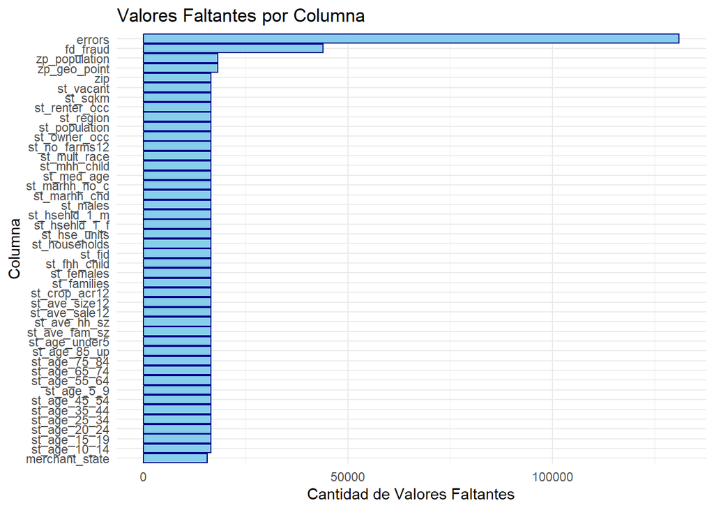

```r
library(tidyr)

# Calcular la cantidad de valores faltantes por columna
missing_values <- transactions_data %>%
  summarise_all(~sum(is.na(.))) %>%
  gather() %>%
  arrange(desc(value))

# Eliminar las columnas sin valores faltantes
missing_values <- missing_values %>%
  filter(value > 0)

# Crear un gráfico de barras con los valores faltantes que no sean cero
ggplot(missing_values, aes(x = reorder(key, value), y = value)) +
  geom_bar(stat = "identity", fill = "skyblue", color = "darkblue") +
  coord_flip() +
  labs(title = "Valores Faltantes por Columna",
       x = "Columna",
       y = "Cantidad de Valores Faltantes")+
  theme_minimal()
```

Se toma una muestra al azar de las transacciones con valores faltantes en la columna `merchant_state` para analizar si hay algún patrón o razón detrás de estos valores faltantes.

```r
# Seleccionar las transacciones con valores faltantes en merchant_state
missing_state_data <- transactions_data %>%
  filter(is.na(merchant_state))

# Mostrar una muestra de las transacciones con valores faltantes en merchant_state
print(head(missing_state_data))
```

```
## # A tibble: 6 × 73
##         id date                client_id card_id amount use_chip     merchant_id
##      <dbl> <dttm>                  <dbl>   <dbl>  <dbl> <chr>              <dbl>
## 1 14749575 2014-07-28 06:21:00      1789    5130  210.  Online Tran…       45453
## 2  8468126 2010-09-03 16:23:00      1448    4685   28.0 Online Tran…       39021
## 3 21495332 2018-07-08 20:22:00      1293    5260   31.1 Online Tran…       41122
## 4  9179832 2011-02-20 13:34:00      1945    5626  135.  Online Tran…       76210
## 5 20611729 2018-01-02 11:53:00       480    5409 1013.  Online Tran…       45453
## 6 22337070 2019-01-03 09:22:00      1453    1117   22.9 Online Tran…       56276
## # ℹ 66 more variables: merchant_city <chr>, merchant_state <chr>, zip <dbl>,
## #   mcc <dbl>, errors <chr>, fd_fraud <chr>, st_fid <dbl>, st_region <chr>,
## #   st_population <dbl>, st_mult_race <dbl>, st_males <dbl>, st_females <dbl>,
## #   st_age_under5 <dbl>, st_age_5_9 <dbl>, st_age_10_14 <dbl>,
## #   st_age_15_19 <dbl>, st_age_20_24 <dbl>, st_age_25_34 <dbl>,
## #   st_age_35_44 <dbl>, st_age_45_54 <dbl>, st_age_55_64 <dbl>,
## #   st_age_65_74 <dbl>, st_age_75_84 <dbl>, st_age_85_up <dbl>, …
```

Tiene sentido la falta de información en las columnas de estado y ciudad porque se trata de transacciones ONLINE. Para verificar esta hipótesis se analiza la distribución de los valores de la columna `merchant_city` para las transacciones con valores faltantes en `merchant_state`.

```r
# Generar un listado de todos los valores únicos de merchant_city donde merchant_state es NA
unique_cities <- missing_state_data %>%
  select(merchant_city) %>%
  distinct()

unique_cities
```

| merchant_city |
| --- |
| ONLINE |

Se realiza un análisis similar para los valores faltantes en la columna zip

```r
# Seleccionar las transacciones con valores faltantes en zip
missing_zip_data <- transactions_data %>%
  filter(is.na(zip))

# Mostrar una muestra de las transacciones con valores faltantes en zip
print(head(missing_zip_data))
```

```
## # A tibble: 6 × 73
##         id date                client_id card_id amount use_chip     merchant_id
##      <dbl> <dttm>                  <dbl>   <dbl>  <dbl> <chr>              <dbl>
## 1 14101716 2014-03-08 08:03:00       629    5523   12.1 Swipe Trans…       75936
## 2 12041175 2012-12-07 19:58:00      1957    5483   55   Swipe Trans…       43293
## 3 12041864 2012-12-08 05:46:00      1957    5483   86.6 Swipe Trans…       87180
## 4 12001239 2012-11-28 21:41:00         4    3413   50.8 Swipe Trans…       75936
## 5  9531057 2011-05-13 15:55:00       848    5423   58.0 Swipe Trans…       59935
## 6 12001006 2012-11-28 19:58:00         4    3413   32.7 Swipe Trans…       83746
## # ℹ 66 more variables: merchant_city <chr>, merchant_state <chr>, zip <dbl>,
## #   mcc <dbl>, errors <chr>, fd_fraud <chr>, st_fid <dbl>, st_region <chr>,
## #   st_population <dbl>, st_mult_race <dbl>, st_males <dbl>, st_females <dbl>,
## #   st_age_under5 <dbl>, st_age_5_9 <dbl>, st_age_10_14 <dbl>,
## #   st_age_15_19 <dbl>, st_age_20_24 <dbl>, st_age_25_34 <dbl>,
## #   st_age_35_44 <dbl>, st_age_45_54 <dbl>, st_age_55_64 <dbl>,
## #   st_age_65_74 <dbl>, st_age_75_84 <dbl>, st_age_85_up <dbl>, …
```

En este caso el faltante de información en la columna `zip` muestra transacciones que no se realizaron en USA. En estos casos en la columna `merchant_state` está el nombre del país donde se realizó la transaccion. Se lista todos los países donde se realizaron transacciones.

```r
# Generar un listado de todos los valores únicos de merchant_state donde zip es NA
unique_countries <- missing_zip_data %>%
  select(merchant_state) %>%
  distinct()

paste("Paises encontrados: ",length(unique_countries$merchant_state))
```

```
## [1] "Paises encontrados:  63"
```

## Proporción de Transacciones Fraudulentas

Se analiza la proporción de transacciones fraudulentas en el dataset, tomando en cuenta las etiquetas de fraude proporcionadas y las que faltan: hay algunos registros sin etiqueta de fraude para validar el modelo de clasificación.

```r
# Contar los valores únicos de la columna fd_fraud sólo para
# las transacciones con etiqueta de fraude
fraud_proportion <- transactions_data %>%
  filter(!is.na(fd_fraud)) %>%
  count(fd_fraud)

# Agregar una columna con la proporción de transacciones fraudulentas con etiqueta
fraud_proportion$proportion <- fraud_proportion$n / sum(fraud_proportion$n)

fraud_proportion
```

| fd_fraud | n | proportion |
| --- | --- | --- |
| No | 89008 | 0.99855279 |
| Yes | 129 | 0.00144721 |

Existen muy pocas transacciones fraudulentas en el dataset, lo que puede dificultar la detección de patrones de fraude (menos del 0,15%). Para el esfuerzo de predicción de fraude, se debe tener en cuenta el desbalance de clases y aplicar técnicas de muestreo o ponderación para mejorar la precisión del modelo.

## Distribución de Montos de Transacciones

Se analiza la distribución de los montos de transacciones para identificar posibles patrones o anomalías.

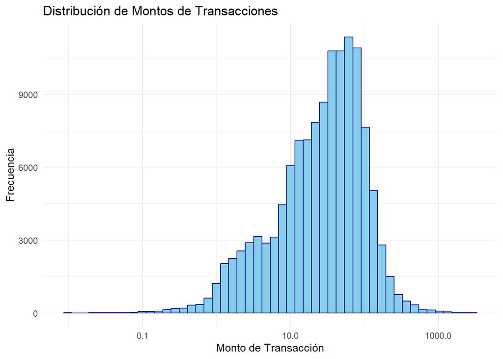

## Distribución de Edades de Clientes

Se analiza la distribución de las edades de los clientes para identificar posibles patrones o anomalías.

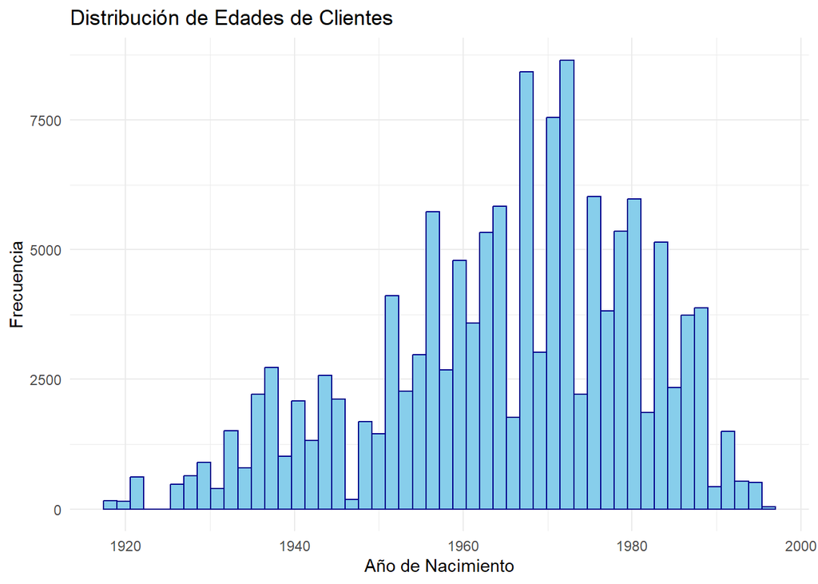

```r
# Generar un histograma de edades
ggplot(transactions_data, aes(x = ud_birth_year)) +
  geom_histogram(fill = "skyblue", color = "darkblue", bins = 50) +
  labs(title = "Distribución de Edades de Clientes",
       x = "Año de Nacimiento",
       y = "Frecuencia") +
  theme_minimal()
```

## Distribución de montos de transacciones por estado

Se analiza la distribución de los montos de transacciones por estado para identificar posibles patrones o anomalías. Se filtra sólo las transacciones dentro de USA.

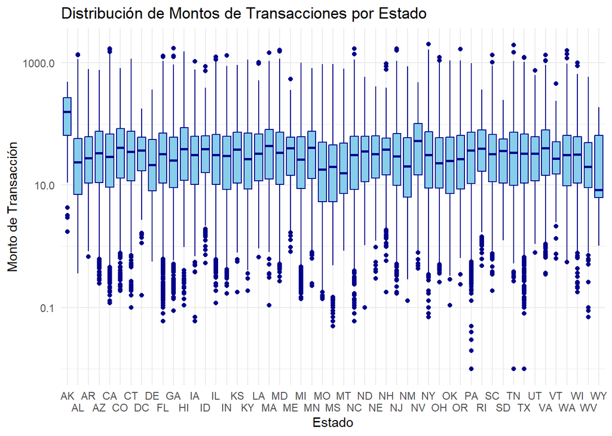

```r
# Generar un gráfico de cajas de montos de transacciones por
# estado con escala logarítmica solo para transacciones en USA

transactions_data_usa <- transactions_data %>%
  filter(merchant_state != "NA" & zip != "NA")

# Filtrar y preparar datos
transactions_clean <- transactions_data_usa %>%
  filter(!is.na(amount) & amount > 0)

# Gráfico con etiquetas alternadas
ggplot(transactions_clean, aes(x = merchant_state, y = amount)) +
  geom_boxplot(fill = "skyblue", color = "darkblue") +
  scale_y_log10() +
  labs(title = "Distribución de Montos de Transacciones por Estado",
       x = "Estado",
       y = "Monto de Transacción") +
  scale_x_discrete(labels = function(x) {
    ifelse(seq_along(x) %% 2 == 0, paste0("\n", x), x)
  }) +
  theme_minimal()
```

Como se puede observar, la distribución de montos de transacciones varía entre los diferentes estados, lo que podría indicar diferencias en los hábitos de consumo o en la actividad económica.

## Distribución de cantidad y monto de transacciones por mes del año

Se analiza la distribución de la cantidad de transacciones por mes del año para identificar patrones estacionales.

```r
# Extraer el mes de la fecha de transacción
transactions_data$month <- as.integer(format(as.Date(transactions_data$date, "%Y-%m-%d"), "%m"))
```

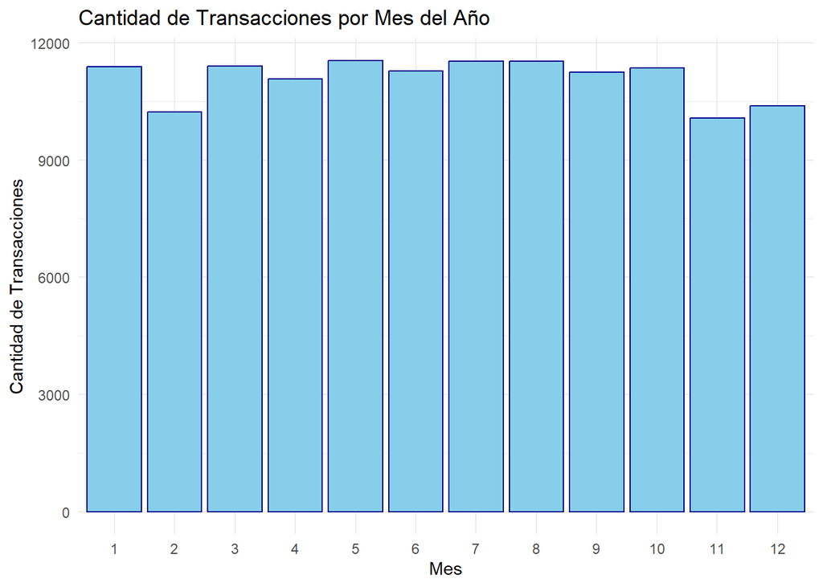

```r
# Generar un dataframe con la cantidad de transacciones por mes
transactions_by_month <- transactions_data %>%
  group_by(month) %>%
  summarise(total_transactions = n())

# Generar un gráfico de barras con la cantidad de transacciones
# por mes del año
ggplot(transactions_by_month, aes(x = factor(month), y = total_transactions)) +
  geom_bar(stat = "identity", fill = "skyblue", color = "darkblue") +
  labs(title = "Cantidad de Transacciones por Mes del Año",
       x = "Mes",
       y = "Cantidad de Transacciones") +
  theme_minimal()
```

Se analiza ahora la distribución del monto total de transacciones por mes del año para identificar patrones estacionales.

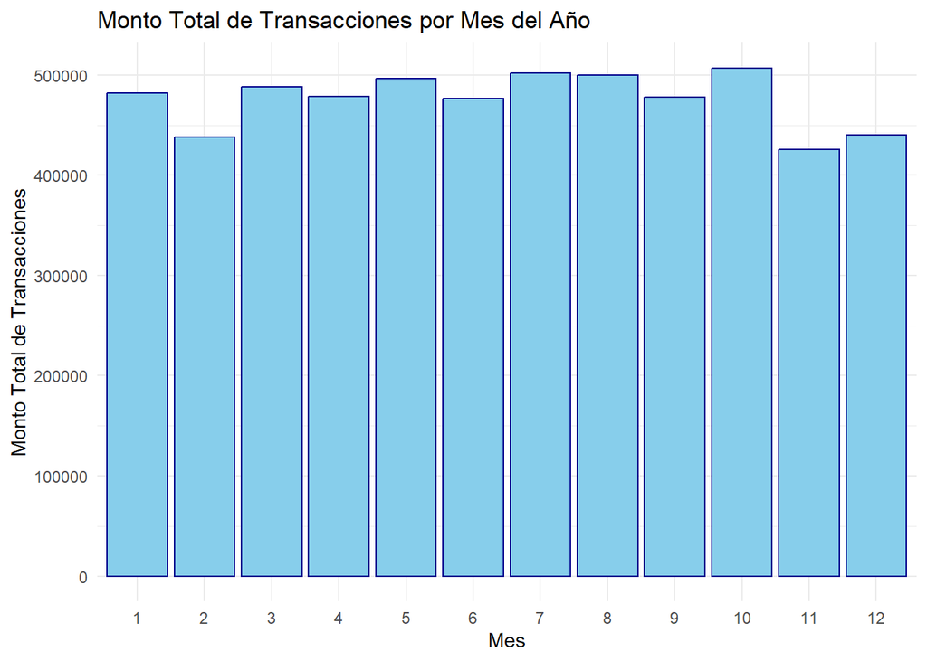

```r
# Generar un dataframe con el monto total de transacciones por mes
total_amount_by_month <- transactions_data %>%
  group_by(month) %>%
  summarise(total_amount = sum(amount))

# Generar un gráfico de barras con el
# monto total de transacciones por mes del año
ggplot(total_amount_by_month, aes(x = factor(month), y = total_amount)) +
  geom_bar(stat = "identity", fill = "skyblue", color = "darkblue") +
  labs(title = "Monto Total de Transacciones por Mes del Año",
       x = "Mes",
       y = "Monto Total de Transacciones") +
  theme_minimal()
```

## Buscando Correlaciones

Se analiza la correlación entre las variables numéricas del dataset para identificar posibles relaciones entre ellas.

Por ser un dataset con muchas variables, se utiliza una matriz de correlación para visualizar las relaciones entre las variables numéricas. En primer lugar sólo para las variables numéricas de datos de demograficos (transacciones y georreferencias) y luego para datos financieros de usuarios (transacciones y usuarios)

```r
# Seleccionar las columnas numéricas de los datos de transacciones y los que
# comienzan con st_ además de las 7 primeras columnas del dataset
# sin prefijo (las de originales)

demo_data_st <- transactions_data %>%
  select(1:7, starts_with("st_"))

# Eliminar las columnas de la pirámide demográfica
# columnas que inicien con st_age_
demo_data_st <- demo_data_st %>%
  select(-starts_with("st_age_"))

# filtrar solo las columnas numéricas
demo_data_st <- demo_data_st %>%
  select_if(is.numeric)

# Calcular la matriz de correlación
correlation_matrix_st <- cor(demo_data_st, use = "pairwise.complete.obs")

correlation_matrix_st
```

```
##                          id    client_id       card_id       amount
## id             1.0000000000 -0.008281650  0.0052712494 -0.004370572
## client_id     -0.0082816500  1.000000000 -0.0032471300 -0.006846377
## card_id        0.0052712494 -0.003247130  1.0000000000 -0.006851427
## amount        -0.0043705720 -0.006846377 -0.0068514275  1.000000000
## merchant_id   -0.0037999413  0.001508306 -0.0064711619 -0.012025453
## st_fid        -0.0028029071 -0.003813136 -0.0050527145  0.008018992
## st_population  0.0014536629 -0.041732878  0.0230036002  0.007659903
## st_mult_race   0.0040448905 -0.032538235  0.0287513165  0.007234111
## st_males       0.0017806254 -0.040698507  0.0229901470  0.007703237
## st_females     0.0017411232 -0.040533181  0.0227668036  0.008077597
## st_med_age     0.0012474504  0.031094442  0.0009783275  0.003474035
## st_households  0.0012877904 -0.039914028  0.0223926299  0.008194594
## st_ave_hh_sz   0.0024510607 -0.025864610  0.0101455891  0.011562799
## st_hsehld_1_m  0.0006276168 -0.039231677  0.0207327344  0.008481992
## st_hsehld_1_f  0.0010536415 -0.036694254  0.0206226489  0.010108719
## st_marhh_chd   0.0017762829 -0.043051566  0.0220797570  0.007348100
## st_marhh_no_c  0.0007862186 -0.038475865  0.0224164029  0.007452686
## st_mhh_child   0.0018082514 -0.040777890  0.0251655151  0.005393155
## st_fhh_child   0.0004063785 -0.043241554  0.0215567755  0.006979578
## st_families    0.0013216852 -0.041069138  0.0225220176  0.007600711
## st_ave_fam_sz  0.0021575182 -0.025578985  0.0035412054  0.014749418
## st_hse_units   0.0008981380 -0.038821668  0.0224239220  0.007928408
## st_vacant     -0.0027132737 -0.024071080  0.0198472282  0.004529172
## st_owner_occ   0.0001660596 -0.039586438  0.0197452962  0.006796532
## st_renter_occ  0.0026555105 -0.039257817  0.0251037853  0.009723305
## st_no_farms12 -0.0046623465 -0.046834387  0.0053027191 -0.009381591
## st_ave_size12 -0.0009230755 -0.019296811 -0.0173645980 -0.007296698
## st_crop_acr12 -0.0051043093 -0.030499863 -0.0080181686 -0.013121725
## st_ave_sale12  0.0081117287 -0.015733091  0.0291855070 -0.005119910
## st_sqkm       -0.0031885996 -0.048298612  0.0055803050 -0.002855266
##                 merchant_id       st_fid st_population st_mult_race
## id            -0.0037999413 -0.002802907  0.0014536629  0.004044890
## client_id      0.0015083061 -0.003813136 -0.0417328776 -0.032538235
## card_id       -0.0064711619 -0.005052715  0.0230036002  0.028751317
## amount        -0.0120254531  0.008018992  0.0076599029  0.007234111
## merchant_id    1.0000000000  0.001934158 -0.0003957651  0.001833874
## st_fid         0.0019341583  1.000000000 -0.4266941832 -0.570650975
## st_population -0.0003957651 -0.426694183  1.0000000000  0.941459620
## st_mult_race   0.0018338743 -0.570650975  0.9414596203  1.000000000
```

[output cut: 193 more lines]

```
## st_marhh_chd    0.645197007  0.696342018
## st_marhh_no_c   0.580795790  0.609745721
## st_mhh_child    0.680032687  0.662248856
## st_fhh_child    0.546739964  0.670510121
## st_families     0.614859520  0.651616065
## st_ave_fam_sz   0.609169609  0.642674946
## st_hse_units    0.588717782  0.624389871
## st_vacant       0.342233059  0.511108462
## st_owner_occ    0.550862133  0.645375557
## st_renter_occ   0.662793060  0.589839959
## st_no_farms12  -0.038558236  0.835183033
## st_ave_size12   0.080871230  0.422369476
## st_crop_acr12   0.090806750  0.659928531
## st_ave_sale12   1.000000000  0.291769460
## st_sqkm         0.291769460  1.000000000
```

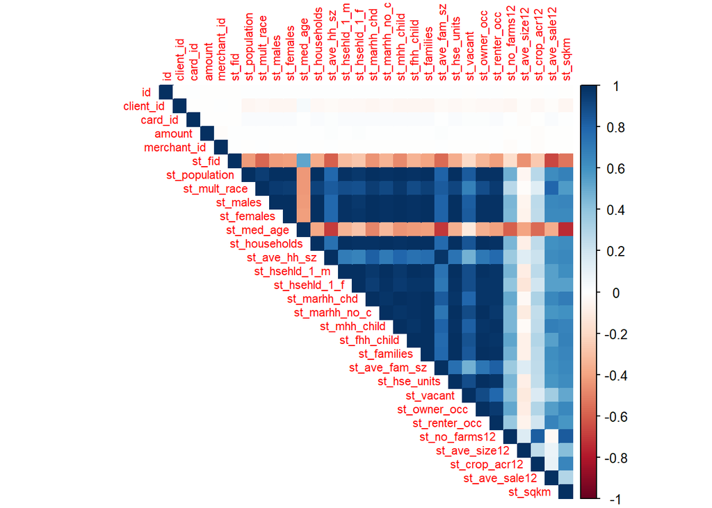

```r
# Generar un gráfico de la matriz de correlación
corrplot::corrplot(correlation_matrix_st, method = "color", type = "upper", tl.cex = 0.7)
```

```r
# Seleccionar las columnas numéricas de los datos de transacciones y los que
# comienzan con st_age además de las 7 primeras columnas del dataset
# sin prefijo (las de originales)

demo_data_st_age <- transactions_data %>%
  select(1:7, starts_with("st_age_"))

# filtrar solo las columnas numéricas
demo_data_st_age <- demo_data_st_age %>%
  select_if(is.numeric)

# Calcular la matriz de correlación
correlation_matrix_st_age <- cor(demo_data_st_age, use = "pairwise.complete.obs")

correlation_matrix_st_age
```

```
##                         id    client_id      card_id       amount
## id             1.000000000 -0.008281650  0.005271249 -0.004370572
## client_id     -0.008281650  1.000000000 -0.003247130 -0.006846377
## card_id        0.005271249 -0.003247130  1.000000000 -0.006851427
## amount        -0.004370572 -0.006846377 -0.006851427  1.000000000
## merchant_id   -0.003799941  0.001508306 -0.006471162 -0.012025453
## st_age_under5  0.001395543 -0.044528646  0.022305757  0.006225103
## st_age_5_9     0.001342947 -0.044336381  0.021741131  0.006382611
## st_age_10_14   0.001565984 -0.042941020  0.022174485  0.006646927
## st_age_15_19   0.002004640 -0.041511986  0.022685134  0.007220426
## st_age_20_24   0.002065462 -0.041581810  0.023221695  0.007922881
## st_age_25_34   0.001899428 -0.042105092  0.022924574  0.007918015
## st_age_35_44   0.001959401 -0.041177886  0.023086357  0.008167027
## st_age_45_54   0.001877524 -0.038687477  0.022571567  0.008715045
## st_age_55_64   0.001775512 -0.038068889  0.023403121  0.008469469
## st_age_65_74   0.001080918 -0.035087519  0.023569698  0.008155368
## st_age_75_84   0.001360719 -0.032493032  0.021742463  0.008846333
## st_age_85_up   0.002245649 -0.029564785  0.021150471  0.010267325
##                   merchant_id st_age_under5    st_age_5_9  st_age_10_14
## id            -0.003799941284  0.0013955431  0.0013429471  0.0015659841
## client_id      0.001508306088 -0.0445286459 -0.0443363809 -0.0429410200
## card_id       -0.006471161891  0.0223057567  0.0217411310  0.0221744853
## amount        -0.012025453111  0.0062251031  0.0063826108  0.0066469271
## merchant_id    1.000000000000 -0.0009086443 -0.0009901431 -0.0007800684
## st_age_under5 -0.000908644329  1.0000000000  0.9998470136  0.9990374045
## st_age_5_9    -0.000990143092  0.9998470136  1.0000000000  0.9991938966
## st_age_10_14  -0.000780068357  0.9990374045  0.9991938966  1.0000000000
## st_age_15_19  -0.000630026959  0.9951888743  0.9952354416  0.9982557272
## st_age_20_24  -0.000502674683  0.9932995869  0.9931200745  0.9965565191
## st_age_25_34  -0.000157554012  0.9960209666  0.9956833417  0.9979589421
## st_age_35_44   0.000004235185  0.9938568616  0.9939188010  0.9971420418
## st_age_45_54  -0.000282498887  0.9861300498  0.9868554818  0.9917714200
## st_age_55_64  -0.000320944378  0.9777881323  0.9787742030  0.9848292555
## st_age_65_74  -0.000015660385  0.9502007569  0.9515413766  0.9589014901
## st_age_75_84  -0.000016316778  0.9261191570  0.9279358493  0.9377496075
## st_age_85_up   0.000262222146  0.9119098139  0.9136461082  0.9265852304
##               st_age_15_19  st_age_20_24 st_age_25_34    st_age_35_44
## id             0.002004640  0.0020654616  0.001899428  0.001959401475
## client_id     -0.041511986 -0.0415818104 -0.042105092 -0.041177886089
## card_id        0.022685134  0.0232216952  0.022924574  0.023086356761
```

[output cut: 35 more lines]

```
## card_id        0.0211504710
## amount         0.0102673255
## merchant_id    0.0002622221
## st_age_under5  0.9119098139
## st_age_5_9     0.9136461082
## st_age_10_14   0.9265852304
## st_age_15_19   0.9420915317
## st_age_20_24   0.9467559705
## st_age_25_34   0.9368261247
## st_age_35_44   0.9476477958
## st_age_45_54   0.9655540298
## st_age_55_64   0.9761495347
## st_age_65_74   0.9852716372
## st_age_75_84   0.9938511134
## st_age_85_up   1.0000000000
```

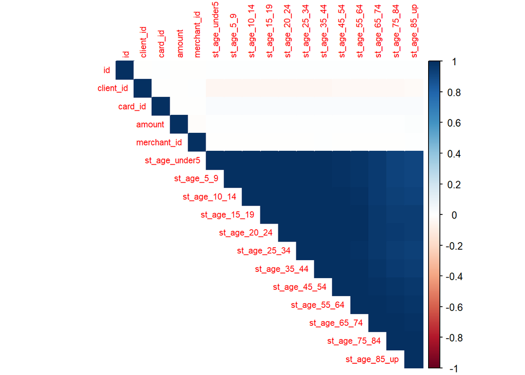

```r
# Generar un gráfico de la matriz de correlación
corrplot::corrplot(correlation_matrix_st_age, method = "color", type = "upper", tl.cex = 0.7)
```

Parece haber poca correlación entre las variables numéricas de los datos demograficos y los de las transacciones financieras. Esto puede indicar - Efectivamente las variables demográficas y financieras son independientes entre sí. - La falta de correlación puede deberse a la falta de información verdadera: se sabe que los datos de las transacciones son sintéticos y no se puede no reflejar hábitos que si se podrían deducir a partir de las variables demográficas. Esto es, los datos demográficos son reales y no se pueden correlacionar con datos ficticios.

```r
library(dplyr)

# Seleccionar las columnas numéricas de los datos de transacciones y los que
# comienzan con ud_ además de las 7 primeras columnas del dataset
# sin prefijo (las de originales)

demo_data_ud <- transactions_data %>%
  select(1:7, starts_with("ud_"))

# filtrar solo las columnas numéricas
demo_data_ud <- demo_data_ud %>%
  select_if(is.numeric)

# Calcular la matriz de correlación
correlation_matrix_ud <- cor(demo_data_ud, use = "pairwise.complete.obs")

correlation_matrix_ud
```

```
##                                 id    client_id      card_id       amount
## id                    1.0000000000 -0.008281650  0.005271249 -0.004370572
## client_id            -0.0082816500  1.000000000 -0.003247130 -0.006846377
## card_id               0.0052712494 -0.003247130  1.000000000 -0.006851427
## amount               -0.0043705720 -0.006846377 -0.006851427  1.000000000
## merchant_id          -0.0037999413  0.001508306 -0.006471162 -0.012025453
## ud_retirement_age    -0.0001551652 -0.017160987  0.015672774 -0.005993035
## ud_birth_year         0.0263721412 -0.056983114 -0.005261465  0.001874707
## ud_birth_month       -0.0045817458  0.007687654 -0.010728907 -0.007249753
## ud_per_capita_income  0.0062448001  0.085138357  0.026947875  0.103166889
## ud_yearly_income      0.0076919281  0.062601704  0.025156152  0.100089351
## ud_total_debt         0.0101362816  0.048364097  0.008185132  0.040224773
## ud_credit_score      -0.0016494296 -0.013627721 -0.037230622 -0.010430662
## ud_num_credit_cards  -0.0111989753 -0.002533761  0.007736372 -0.005912042
##                        merchant_id ud_retirement_age ud_birth_year
## id                   -0.0037999413     -0.0001551652   0.026372141
## client_id             0.0015083061     -0.0171609872  -0.056983114
## card_id              -0.0064711619      0.0156727736  -0.005261465
## amount               -0.0120254531     -0.0059930346   0.001874707
## merchant_id           1.0000000000     -0.0013120040  -0.001175376
## ud_retirement_age    -0.0013120040      1.0000000000   0.008063112
## ud_birth_year        -0.0011753763      0.0080631124   1.000000000
## ud_birth_month       -0.0061504161      0.0033845827  -0.002493221
## ud_per_capita_income -0.0088921473     -0.0390730571  -0.004563644
## ud_yearly_income     -0.0053393844     -0.0028600484   0.123069581
## ud_total_debt         0.0006538274     -0.0280120472   0.384012731
## ud_credit_score       0.0047549625      0.1637740920   0.020205690
## ud_num_credit_cards   0.0344255873      0.1525064611  -0.386786462
##                      ud_birth_month ud_per_capita_income ud_yearly_income
## id                     -0.004581746          0.006244800      0.007691928
## client_id               0.007687654          0.085138357      0.062601704
## card_id                -0.010728907          0.026947875      0.025156152
## amount                 -0.007249753          0.103166889      0.100089351
## merchant_id            -0.006150416         -0.008892147     -0.005339384
## ud_retirement_age       0.003384583         -0.039073057     -0.002860048
## ud_birth_year          -0.002493221         -0.004563644      0.123069581
## ud_birth_month          1.000000000         -0.010767400     -0.000832145
## ud_per_capita_income   -0.010767400          1.000000000      0.948938665
## ud_yearly_income       -0.000832145          0.948938665      1.000000000
## ud_total_debt          -0.008710829          0.429485754      0.495283654
## ud_credit_score        -0.053839608         -0.048241779     -0.044506123
## ud_num_credit_cards    -0.024615289          0.009702653     -0.046388504
##                      ud_total_debt ud_credit_score ud_num_credit_cards
## id                    0.0101362816    -0.001649430        -0.011198975
## client_id             0.0483640965    -0.013627721        -0.002533761
## card_id               0.0081851322    -0.037230622         0.007736372
## amount                0.0402247732    -0.010430662        -0.005912042
## merchant_id           0.0006538274     0.004754962         0.034425587
## ud_retirement_age    -0.0280120472     0.163774092         0.152506461
## ud_birth_year         0.3840127309     0.020205690        -0.386786462
## ud_birth_month       -0.0087108286    -0.053839608        -0.024615289
## ud_per_capita_income  0.4294857545    -0.048241779         0.009702653
## ud_yearly_income      0.4952836543    -0.044506123        -0.046388504
## ud_total_debt         1.0000000000    -0.120946057        -0.209854954
## ud_credit_score      -0.1209460569     1.000000000         0.245446900
## ud_num_credit_cards  -0.2098549538     0.245446900         1.000000000
```

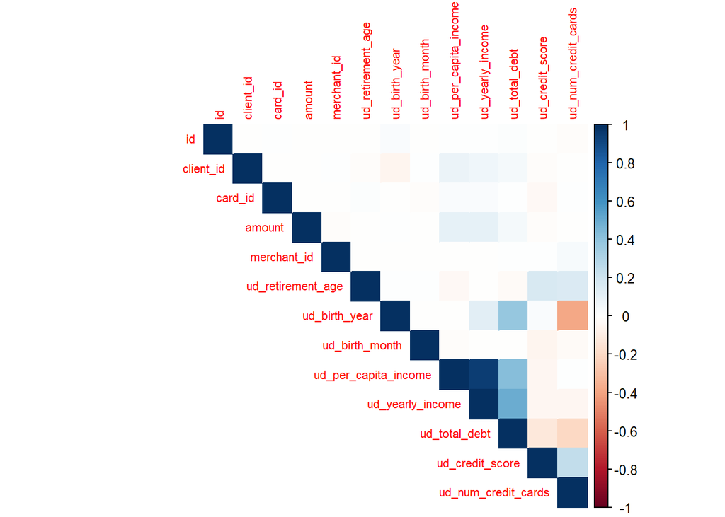

```r
# Generar un gráfico de la matriz de correlación
corrplot::corrplot(correlation_matrix_ud, method = "color", type = "upper", tl.cex = 0.7)
```

# Analisis de Regresión

Para analizar la relación entre las variables financieras de los usuarios y las transacciones, se realiza un análisis de regresión lineal. Se seleccionan las variables financieras de los usuarios como variables independientes.

Las variables financieras de los usuarios seleccionadas son: - `ud_per_capita_income`: Ingreso per cápita del usuario. - `ud_total_debt`: Deuda total del usuario. - `cd_credit_limit`: Límite de crédito de la tarjeta del usuario.

Con estas variables se intenta predecir el monto de la transacción (`amount`). Primeramente se intenta predecir el monto de la transacción a partir cada una de las variables financieras de los usuarios (modelos univariados) y luego se intenta predecir el monto de la transacción a partir de la commbinación de todas las variables financieras de los usuarios (modelo multivariado).

```r
# Seleccionar las variables financieras de los usuarios y
# el monto de la transacción
# Modelo 1: Ingreso per cápita del usuario vs Monto de la transacción

model_income <- lm(amount ~ ud_per_capita_income, data = transactions_data)

summary(model_income)
```

```
##
## Call:
## lm(formula = amount ~ ud_per_capita_income, data = transactions_data)
##
## Residuals:
##     Min      1Q  Median      3Q     Max
## -575.32  -32.92  -13.58   21.45 2922.05
##
## Coefficients:
##                         Estimate  Std. Error t value            Pr(>|t|)
## (Intercept)          26.06968683  0.49824054   52.32 <0.0000000000000002 ***
## ud_per_capita_income  0.00070465  0.00001863   37.83 <0.0000000000000002 ***
## ---
## Signif. codes:  0 '***' 0.001 '**' 0.01 '*' 0.05 '.' 0.1 ' ' 1
##
## Residual standard error: 80.92 on 133032 degrees of freedom
## Multiple R-squared:  0.01064,    Adjusted R-squared:  0.01064
## F-statistic:  1431 on 1 and 133032 DF,  p-value: < 0.00000000000000022
```

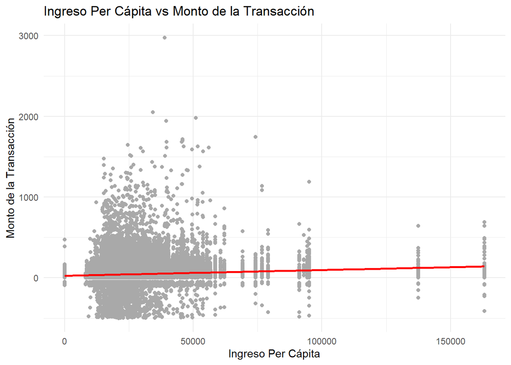

```r
# Diagrama de dispersión
# con recta de regresión en color rojo
ggplot(transactions_data, aes(x = ud_per_capita_income, y = amount)) +
  geom_point(color = "darkgrey") +
  geom_smooth(method = "lm", color = "red") +
  labs(title = "Ingreso Per Cápita vs Monto de la Transacción",
       x = "Ingreso Per Cápita",
       y = "Monto de la Transacción") +
  theme_minimal()
```

```r
# Modelo 2: Deuda total del usuario vs Monto de la transacción
model_debt <- lm(amount ~ ud_total_debt, data = transactions_data)

summary(model_debt)
```

```
##
## Call:
## lm(formula = amount ~ ud_total_debt, data = transactions_data)
##
## Residuals:
##     Min      1Q  Median      3Q     Max
## -553.36  -34.01  -13.65   20.83 2935.99
##
## Coefficients:
##                   Estimate   Std. Error t value            Pr(>|t|)
## (Intercept)   39.296387283  0.333869322  117.70 <0.0000000000000002 ***
## ud_total_debt  0.000062924  0.000004285   14.68 <0.0000000000000002 ***
## ---
## Signif. codes:  0 '***' 0.001 '**' 0.01 '*' 0.05 '.' 0.1 ' ' 1
##
## Residual standard error: 81.29 on 133032 degrees of freedom
## Multiple R-squared:  0.001618,   Adjusted R-squared:  0.001611
## F-statistic: 215.6 on 1 and 133032 DF,  p-value: < 0.00000000000000022
```

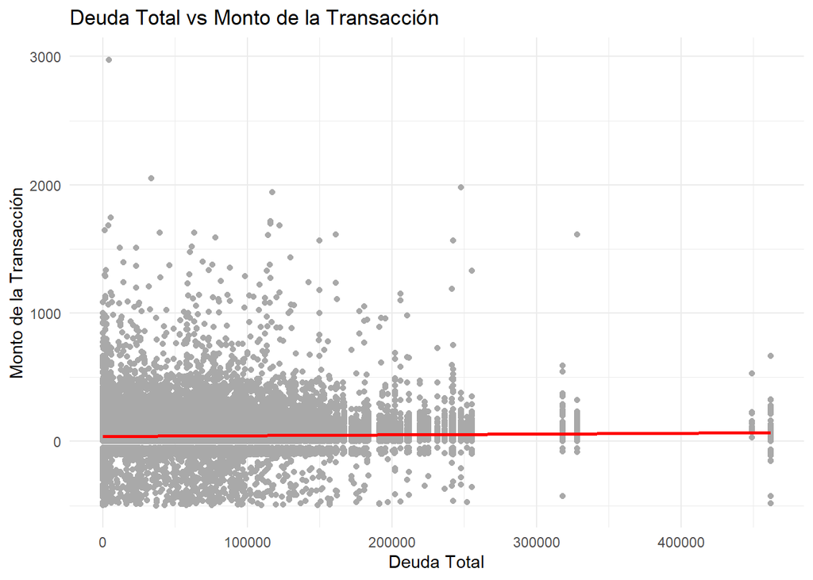

```r
# Diagrama de dispersión
# con recta de regresión en color rojo
ggplot(transactions_data, aes(x = ud_total_debt, y = amount)) +
  geom_point(color = "darkgrey") +
  geom_smooth(method = "lm", color = "red") +
  labs(title = "Deuda Total vs Monto de la Transacción",
       x = "Deuda Total",
       y = "Monto de la Transacción") +
  theme_minimal()
```